# Tastermonial Food Comparisons: Goodidea Drink

Richard Sprague

2021-09-03

# Good Idea®

GoodIdea®, “the Swedish sugar buster”, is a sparkling soft drink formulated with a proprietary blend of ingredients that claims to lower overall glucose levels when consumed before a meal. How well does it work for me?

[figure not shown]

## My Personal Science Experiment

Wearing a continuous glucose monitor (CGM) on three different mornings on an empty stomach, I ate a bowl of Cream of Wheat mixed with 1/4 cup heavy cream and 1 TBS butter. This meal is about 500 calories, including 50g of net carbs and 35g of fat. I wanted a food that is generally considered “healthy”, with no sugar content, but high carb. I served it with a generous amount of fat to avoid significant glucose spikes.

I finished within five minutes and then I remained as sedentary as possible for the next two hours.

[figure not shown]

On one of those mornings I drank a can of Good Idea® fifteen minutes before the meal.

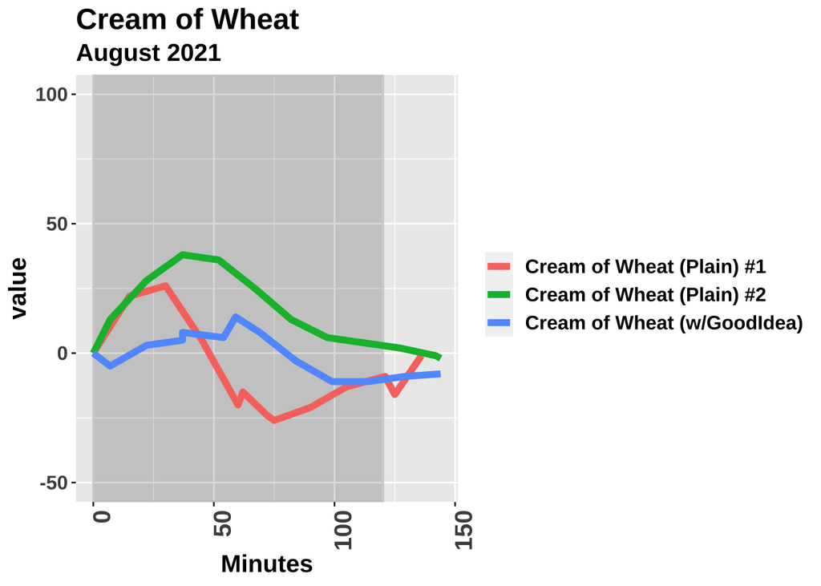

This chart shows an obvious spike soon after plain Cream of Wheat meals, climbing at least 20 points within the first half hour. (Note: the values here are normalized so all meals start at 0). By contrast, the meal that followed a glass of Good Idea® seemed more stable.

| meal | auc | min | max | rise |
| --- | --- | --- | --- | --- |
| Cream of Wheat (Plain) #1 | -587.0 | 73 | 125 | -16 |
| Cream of Wheat (w/GoodIdea) | 516.5 | 83 | 108 | 19 |
| Cream of Wheat (Plain) #2 | 540.5 | 85 | 125 | -15 |